# By using the given Patient Appointment show/noshow excel data, This project plots the overall show and noshow count

# Answer 1 : Based on the above Bar chart, we could see that Show/Noshow percentage is same for both Female and male. Hence the Gender does not impact the show/noshow. In general 80% of the male/female have showed their presence and 20% did not show their presence

# Question 2 : Does the SMS Remainder play role in Noshow/Show ?

```
  SMS_received No-show  percentage value for category
0           No      No                      83.299128
1           No     Yes                      16.700872
2          Yes      No                      72.424678
3          Yes     Yes                      27.575322
```

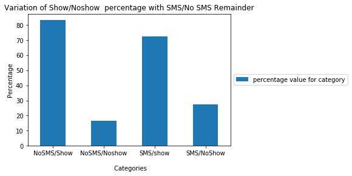

```python
# Read the cleanedup data

df_data = pd.read_csv('noshowappointments_clean.csv')



df_remainder = df_data.groupby(['SMS_received','No-show'])['PatientId'].count()

df_pct = df_remainder.groupby(['SMS_received']).apply(lambda x:100 * (x/float(x.sum())))
pd.options.mode.chained_assignment = None

df_pct = df_pct.reset_index()
df_pct=df_pct.rename(columns = {'PatientId':'percentage value for category'})

df_pct.SMS_received[df_pct.SMS_received == 0] = "No"
df_pct.SMS_received[df_pct.SMS_received == 1] = "Yes"
print(df_pct)

#statements to plot the graph
barc1 = df_pct.plot.bar()
slist1 = ['NoSMS/Show','NoSMS/Noshow','SMS/show','SMS/NoShow']
barc1.set_xticklabels(slist1)
barc1.set_ylabel('Percentage')
barc1.set_xlabel('\n Categories')
barc1.legend(loc='center left', bbox_to_anchor=(1.0, 0.5))
barc1.set_title('Variation of Show/Noshow  percentage with SMS/No SMS Remainder')
for tick in barc1.get_xticklabels():
    tick.set_rotation(0)
```

# Answer 2 : Based on the above Bar chart, we could see that Show/Noshow percentage has gone down based on SMS Remainder - yes there is an impact. When a SMS remainder has been sent, percentage of people who have showed their presence has reduced

# Question 3 : How does the Age-Group play a role in Show/No-show

```
                          Showpercentage  NoShowpercentage
Agegroup
Adult ( age 21 - 60)           79.263697         20.736303
Child ( age  0 - 12)           79.525575         20.474425
Senior ( age > 60 years)       84.798785         15.201215
Teen ( age  13 -20 )           74.204587         25.795413
```

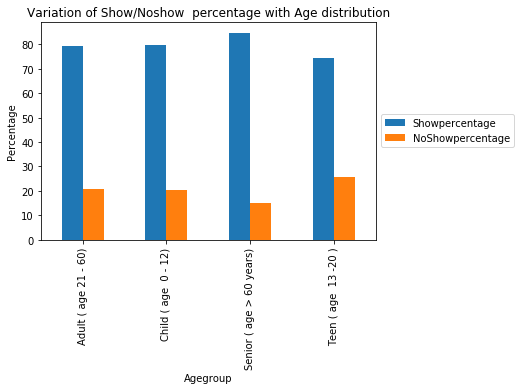

```python
#Define a function to categorise the data based on Age

def classifier(row):
    if row["Age"] >= 0 and row["Age"] <= 12:
        return "Child ( age  0 - 12)"
    elif row["Age"] >= 13 and row["Age"] <= 20:
        return "Teen ( age  13 -20 )"
    elif row["Age"] >= 21 and row["Age"] <= 60:
        return "Adult ( age 21 - 60)"
    else:
        return "Senior ( age > 60 years)"

    # Read the cleanedup data

df_data = pd.read_csv('noshowappointments_clean.csv')


#Introduce a new column by applying the age classifier function
df_data["Agegroup"] = df_data.apply(classifier, axis=1)

df_classify = df_data.groupby(['Agegroup','No-show'])['PatientId'].count()
df_pct = df_classify.groupby(['Agegroup']).apply(lambda x:100 * (x/float(x.sum())))
df_pct.to_csv('noshowpercentage.csv',encoding="utf8",index=True)
df_pctvalue = pd.read_csv('noshowpercentage.csv',header=None)
df_pctvalue.columns = ["Agegroup", "Noshowindicator", "Percentage"]
df_noshow = df_pctvalue.query('Noshowindicator == "Yes" ')
df_show = df_pctvalue.query('Noshowindicator == "No" ')
df_show=df_show.rename(columns = {'Percentage':'Showpercentage'})
df_noshow=df_noshow.rename(columns = {'Percentage':'NoShowpercentage'})

#Data merge to format the data
df_age_plot = df_show.merge(df_noshow,on='Agegroup')

cols = [1,3]
df_age_plot.drop(df_age_plot.columns[cols],axis=1,inplace=True)
#df_age_plot.head()
df_age_plot.set_index('Agegroup', inplace=True)
print(df_age_plot.head(5))
#statements to plot the graph
axx = df_age_plot.plot.bar()
axx.set_ylabel('Percentage')
axx.legend(loc='center left', bbox_to_anchor=(1.0, 0.5))
axx.set_title('Variation of Show/Noshow  percentage with Age distribution')
```